# Correlation between Divorce rate and Income

# 1 Introduction

##### The relation between Income and Divorce rate is a interesting topic.

##### We always would like to know weather we can make our marriage relation firmer by earing more support our family a better life.

##### In order to answer this question, we make this research.

##### Firly, we have to classificate the population into different groups by income. In general, the split of population by income are lower class, middle class and higher class.

##### So, we split the population into three different groups by income and The first 1/3 of them are the people whose income is the lowest 1/3, we name them “Lower Class”. The middle 1/3 of them are the people whose income are middle and we name them “Middle Class” and the we name the rest “Upper Class”.

##### There are another way to classficate the income, I will talk about it detailed below.

##### We will pay attention on the divorce rate in different income group.

##### Forther more, we will pay attention on the affection of different gender and age group.

## 1.1. Setup the Bench

##### Install Package and build environment.

###### (data.table), (readr), (plyr), (ggplot2), (dplyr), (foreach) and (gridExtra)

## 1.2. Read the data

##### Because the limitation of PC, we only read the selected variables from the data set

###### “MARHD” = Divorced in the past 12 months. b. N/A (age less than 15 years or never married) 1.Yes 2. No

###### “MARHM” = Married in the past 12 months.b. N/A (age less than 15 years or never married) 1.Yes 2. No

###### “PERNP” = Total person’s earning.

###### “PINCP” = Total person’s income(signed).

###### “SEX” = Gender 1. Male 2. Female

###### “MAR” = Marital Status 1. Married 2. Windowsed 3. Divorced 4. Separated 5. Never married or under 15 years old.

##### Cause there are two data set, we read them one by one and merge then by rows

```r
setwd("/Users/kaishengwang/Desktop/Applied\ Data\ Science\ Project/Project1/data")
features <- c("MARHD", "MARHM", "PERNP", "PINCP", "AGEP", "SEX", "MAR")
Data1 <- fread('ss13pusa.csv', select = features)
```

```
##
Read 0.0% of 1613672 rows
Read 19.2% of 1613672 rows
Read 39.0% of 1613672 rows
Read 58.3% of 1613672 rows
Read 78.1% of 1613672 rows
Read 97.3% of 1613672 rows
Read 1613672 rows and 7 (of 283) columns from 1.416 GB file in 00:00:09
```

```r
Data2 <- fread('ss13pusb.csv', select = features)
```

```
##
Read 0.0% of 1519123 rows
Read 20.4% of 1519123 rows
Read 40.8% of 1519123 rows
Read 61.2% of 1519123 rows
Read 81.0% of 1519123 rows
Read 1519123 rows and 7 (of 283) columns from 1.333 GB file in 00:00:09
```

```r
Data <- rbind(Data1, Data2)
```

## 1.3 Data Manipulation

##### Data clean, remove the unuseful data and plot the distribution of Income.

```r
Data <- na.omit(Data)
remove(Data1)
remove(Data2)
Data <- subset(Data, MAR != 5)

min(Data$PINCP)
```

```
## [1] -13600
```

```r
#-13600
max(Data$PINCP)
```

```
## [1] 1281000
```

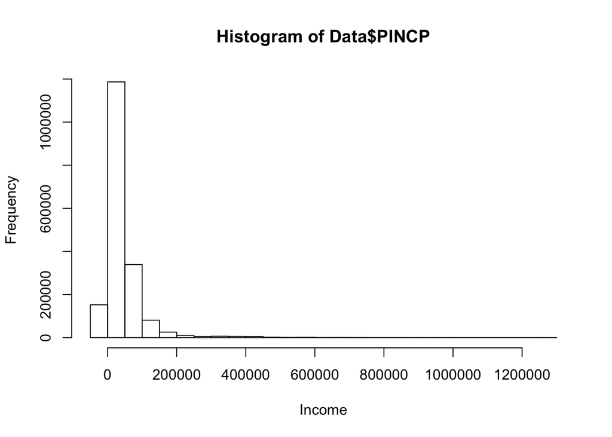

```r
#1281000
hist(Data$PINCP, xlab = "Income")
```

##### This means the classification of income is meanful.

##### But as I mentioned above, there are another way to classficate income. This is Upper Mid Class, Mid Class, Lower Mid Class and Lower Class and the split points are $35,000/Year, $75,000/year, $100,000/year.

##### I will talk them one by one.

##### I would like to talk about data visualization of two kinks of income classfication and the effect of gender and age group.

##### In terms of Divorce rate, there are two kinds of ways to classicate. One is the number of people who have been divorced divoice by the number of people who have been married.Another is the number of people who have been divorce divoice by the number of all population.

##### I will utilize all of them in my code.

# 2 One way to classficate income group.

##### Classficate income by 1/3 and 2/3 of income level.

```r
Data$SEX <- as.factor(Data$SEX)
Income_sort <- sort(Data$PINCP)
One_Third <- Income_sort[round(dim(Data)[1]/3)]
Two_Third <- Income_sort[round(dim(Data)[1]/3)*2]

Data$Income1 <- ifelse(Data$PINCP %in% c(min(Data$PINCP):One_Third), "Low",
                      ifelse(Data$PINCP %in% c(One_Third:Two_Third), "Mid",
                             ("High")))
```

## 2.1 One way to defince divorce rate

##### Divrate1 = people who have been divorce or seperate / number of all people

##### we are also interested in weather gender and age group could affect the divorce rate. So, we will discuss them one by one.

### 2.1.1 Only divorce rate and Income level.

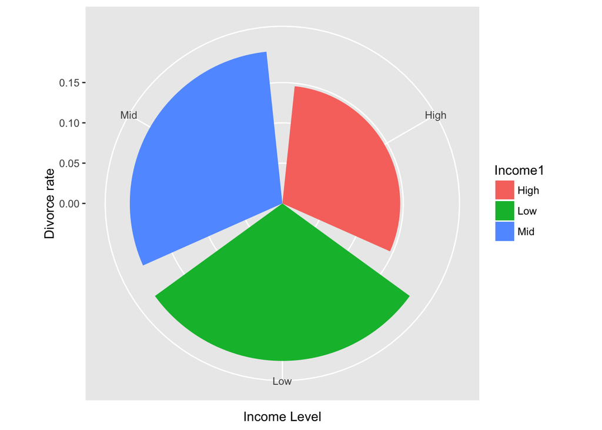

```r
Data_Income1_Divrate1 <- ddply(Data, .(Income1), summarise, n = length(MARHD), Div_rate1 = (sum(MAR == 3) + sum(MAR == 4))/length(MAR))

Income1_Divrate1<- ggplot(Data_Income1_Divrate1, aes(x = factor(Income1), y = Div_rate1, fill = Income1)) +
                     geom_bar(stat = "identity", position = "dodge") +
                     coord_polar(theta = "x") +
                     xlab("Income Level") + ylab("Divorce rate")
Income1_Divrate1
```

##### From the plot, we can know that the low-income and mid-income groups have almost the same divorce rate but the high-income have the lower dicorce rate.

### 2.1.2 The effect of gender.

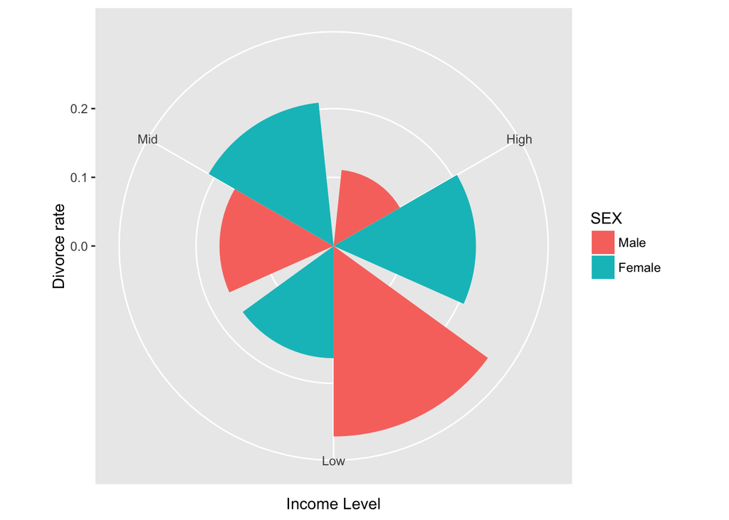

```r
Data_Income1_Divrate1_sex <- ddply(Data, .(Income1, SEX), summarise, n = length(MARHD), Div_rate1 = (sum(MAR == 3) + sum(MAR == 4))/length(MAR))

Income1_sex_Divrate1<- ggplot(Data_Income1_Divrate1_sex, aes(x = factor(Income1), y = Div_rate1, fill = SEX)) +
                     geom_bar(stat = "identity", position = "dodge") +
                     coord_polar(theta = "x") +
                     xlab("Income Level") + ylab("Divorce rate") +
                     scale_fill_discrete(labels = c("Male", "Female"))
Income1_sex_Divrate1
```

##### The results are very interesting!!! In the group of low-income, the divorce rate of male is more than it of female. But in the groups of mid-income and high-income, it’s oppposite. And with the income increase, the divorce rate of female is more and more large and it for male.

### 2.1.3 The effect of agegroup.

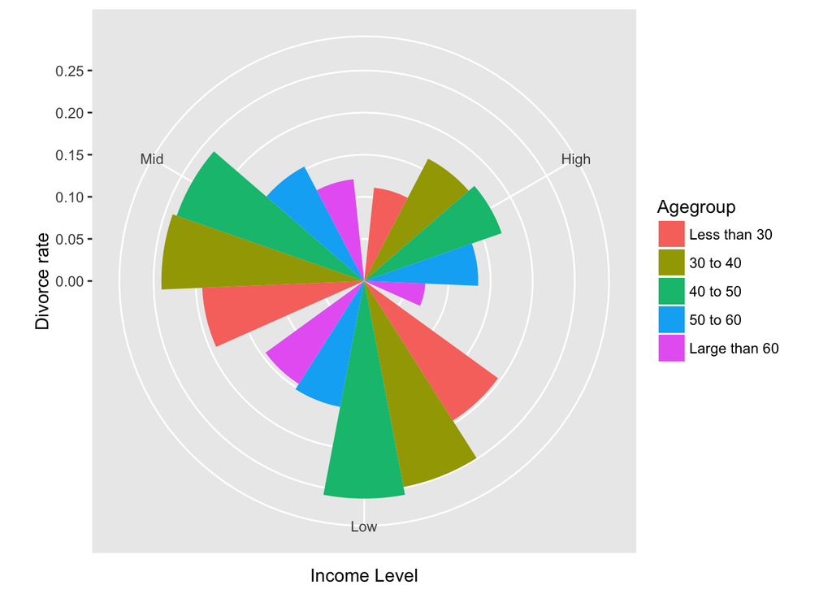

```r
Data$Agegroup <- ifelse(Data$AGEP < 30, "less than 30",
                        ifelse(Data$AGEP %in% c(30:40), "30 to 40",
                               ifelse(Data$AGEP %in% c(40:50), "40 to 50",
                                      ifelse(Data$AGEP %in% c(50:60), "50 to 60",
                                             ("Large than 60")))))
Data_Income1_Divrate1_age <- ddply(Data, .(Income1, Agegroup), summarise, n = length(MARHD), Div_rate1 = (sum(MAR == 3) + sum(MAR == 4))/length(MAR))
Income1_age_Divrate1<- ggplot(Data_Income1_Divrate1_age, aes(x = factor(Income1), y = Div_rate1, fill = Agegroup)) +
                      geom_bar(stat = "identity", position = "dodge") +
                      coord_polar(theta = "x") +
                      xlab("Income Level") + ylab("Divorce rate") +
                      scale_fill_discrete(labels = c("Less than 30", "30 to 40", "40 to 50", "50 to 60", "Large than 60"))
Income1_age_Divrate1
```

## 2.2 Another way to define divorce rate.

##### Divrate2 = poeple who have been divorce in the past 12 months / people who have been married in the past 12 months

### 2.2.1 Only divorce rate and Income level.

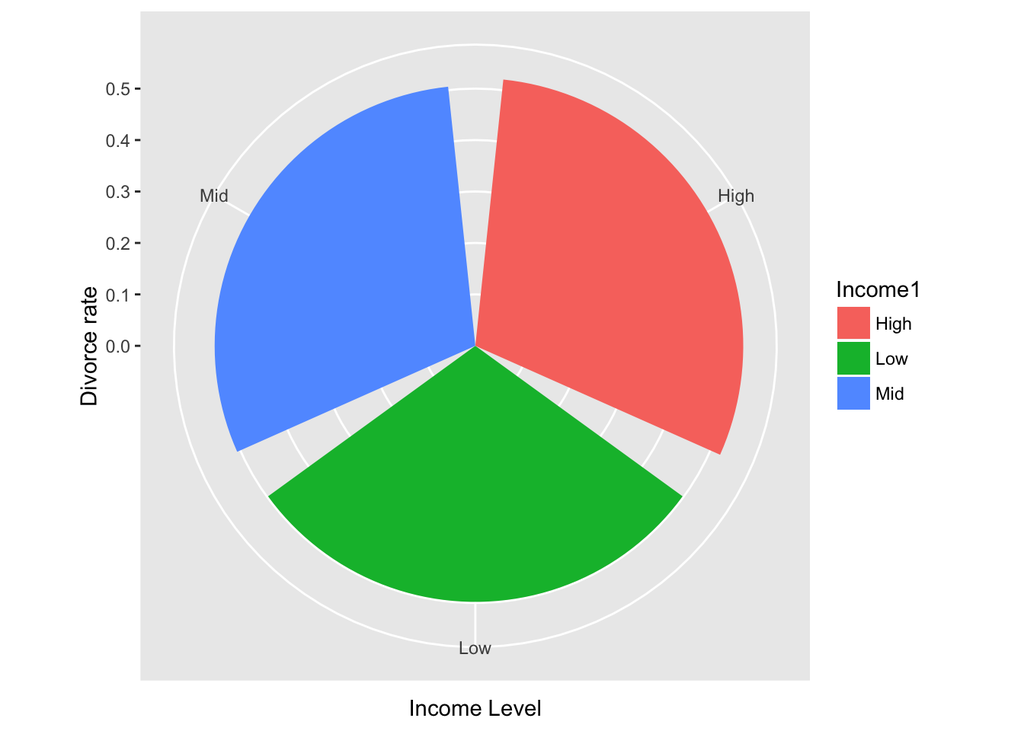

```r
Data_Income1_Divrate2 <- ddply(Data, .(Income1), summarise, n = length(MARHD), Div_rate2 = (sum(MARHD == 1))/(sum(MARHM == 1)))

Income1_Divrate2 <- ggplot(Data_Income1_Divrate2, aes(x = factor(Income1), y = Div_rate2, fill = Income1)) +
                     geom_bar(stat = "identity", position = "dodge") +
                     coord_polar(theta = "x") +
                     xlab("Income Level") + ylab("Divorce rate")
Income1_Divrate2
```

##### The results are not obvious

### 2.2.2 The effect of gender.

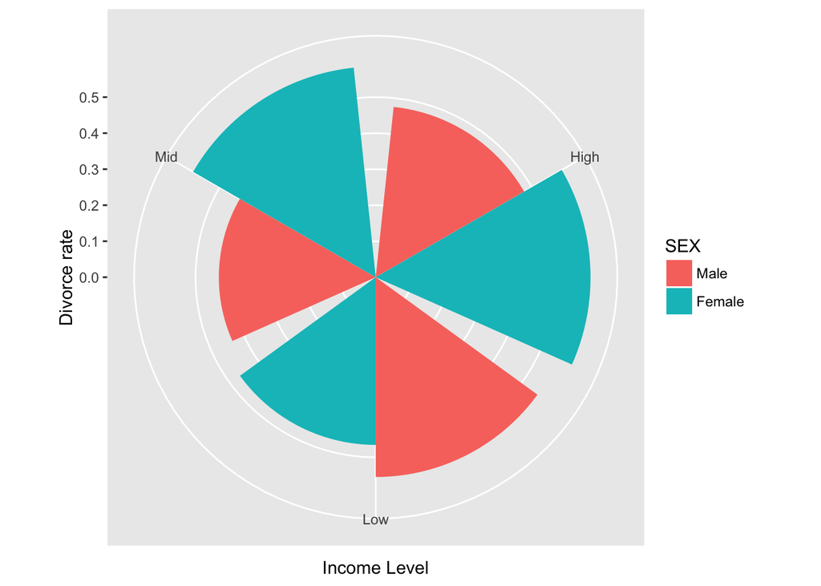

```r
Data_Income1_Divrate2_sex <- ddply(Data, .(Income1, SEX), summarise, n = length(MARHD), Div_rate2 = (sum(MARHD == 1))/(sum(MARHM == 1)))

Income1_sex_Divrate2<- ggplot(Data_Income1_Divrate2_sex, aes(x = factor(Income1), y = Div_rate2, fill = SEX)) +
                     geom_bar(stat = "identity", position = "dodge") +
                     coord_polar(theta = "x") +
                     xlab("Income Level") + ylab("Divorce rate") +
                     scale_fill_discrete(labels = c("Male", "Female"))
Income1_sex_Divrate2
```

##### The results are almost the same with the previous one.

### 2.2.3 The effect of agegroup.

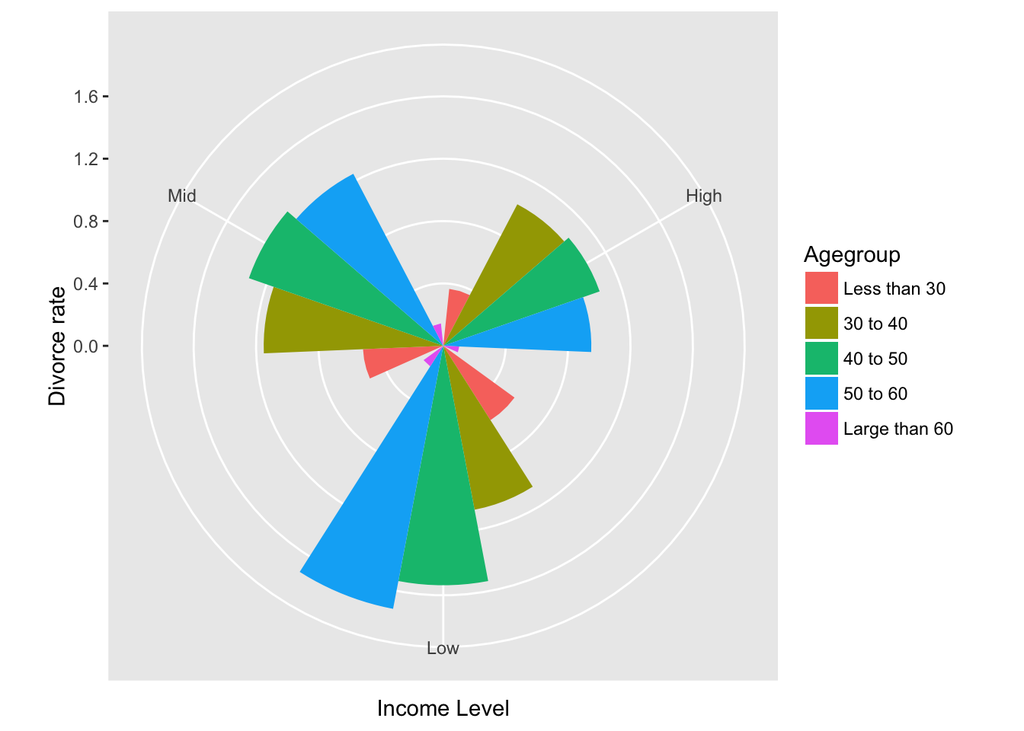

```r
Data$Agegroup <- ifelse(Data$AGEP < 30, "less than 30",
                        ifelse(Data$AGEP %in% c(30:40), "30 to 40",
                               ifelse(Data$AGEP %in% c(40:50), "40 to 50",
                                      ifelse(Data$AGEP %in% c(50:60), "50 to 60",
                                             ("Large than 60")))))
Data_Income1_Divrate2_age <- ddply(Data, .(Income1, Agegroup), summarise, n = length(MARHD), Div_rate2 = (sum(MARHD == 1))/(sum(MARHM == 1)))
Income1_age_Divrate2<- ggplot(Data_Income1_Divrate2_age, aes(x = factor(Income1), y = Div_rate2, fill = Agegroup)) +
                      geom_bar(stat = "identity", position = "dodge") +
                      coord_polar(theta = "x") +
                      xlab("Income Level") + ylab("Divorce rate") +
                      scale_fill_discrete(labels = c("Less than 30", "30 to 40", "40 to 50", "50 to 60", "Large than 60"))
Income1_age_Divrate2
```

# 3 Another way to classficate income group.

##### Classficate income by $35,000/Year, $75,000/Year and $100,000/Year.

##### Upper Mid Class > $100,000/Year

##### $75,000/Year < Mid Class < $100,000/Year

##### $35,000/Year < Lower Mid Class < $75,000/Year

##### Lower Class < $35,000/Year

```r
Income_sort <- sort(Data$PINCP)
Data$Income2 <- ifelse(Data$PINCP < 35000, "Low",
                      ifelse(Data$PINCP %in% c(35000:75000), "Lower Mid",
                             ifelse(Data$PINCP %in% c(75000: 100000), "Mid",
                                    ("Upper Mid"))))
```

## 3.1 One way to define divorce rate.

##### Divrate1 = people who have been divorce or seperate / number of all people

##### we are also interested in weather gender and age group could affect the divorce rate. So, we will discuss them one by one.

### 3.1.1 Only divorce rate and Income level.

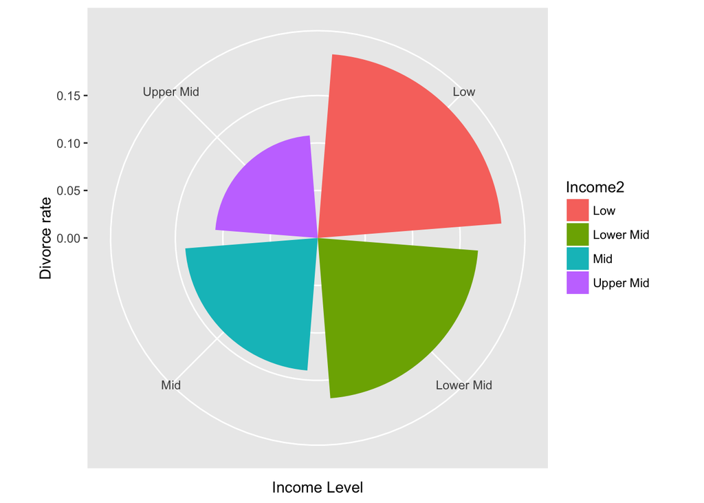

```r
Data_Income2_Divrate1 <- ddply(Data, .(Income2), summarise, n = length(MARHD), Div_rate1 = (sum(MAR == 3) + sum(MAR == 4))/length(MAR))

Income2_Divrate1<- ggplot(Data_Income2_Divrate1, aes(x = factor(Income2), y = Div_rate1, fill = Income2)) +
                     geom_bar(stat = "identity", position = "dodge") +
                     coord_polar(theta = "x") +
                     xlab("Income Level") + ylab("Divorce rate")
Income2_Divrate1
```

##### From the plot, we can know that the result are almost the same with the previous one. With the increase of income, the divorce rate are decreased.

### 3.1.2 The effect of gender.

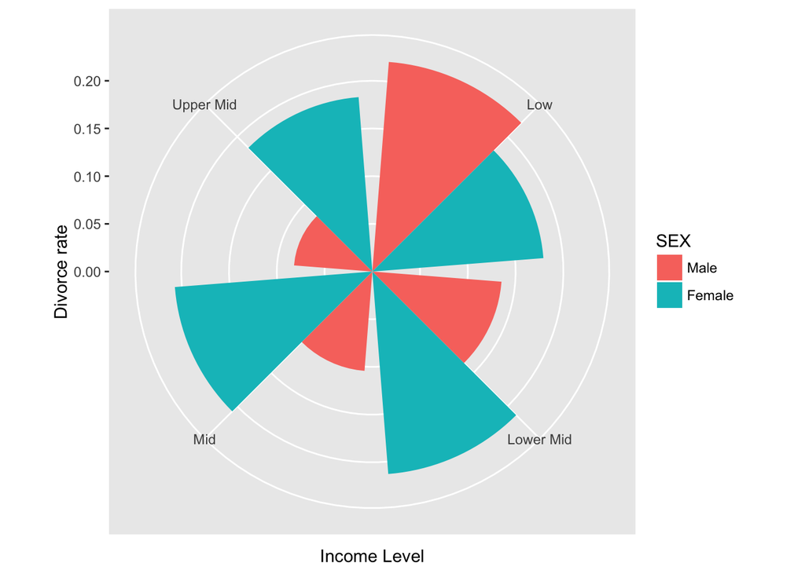

```r
Data_Income2_Divrate1_sex <- ddply(Data, .(Income2, SEX), summarise, n = length(MARHD), Div_rate1 = (sum(MAR == 3) + sum(MAR == 4))/length(MAR))

Income2_sex_Divrate1<- ggplot(Data_Income2_Divrate1_sex, aes(x = factor(Income2), y = Div_rate1, fill = SEX)) +
                     geom_bar(stat = "identity", position = "dodge") +
                     coord_polar(theta = "x") +
                     xlab("Income Level") + ylab("Divorce rate") +
                     scale_fill_discrete(labels = c("Male", "Female"))
Income2_sex_Divrate1
```

##### There are some new results from this plot. With the increase of income, the divorce rate of male will decrease, but the divorce rate of female not change so much.

### 3.1.3 The effect of agegroup.

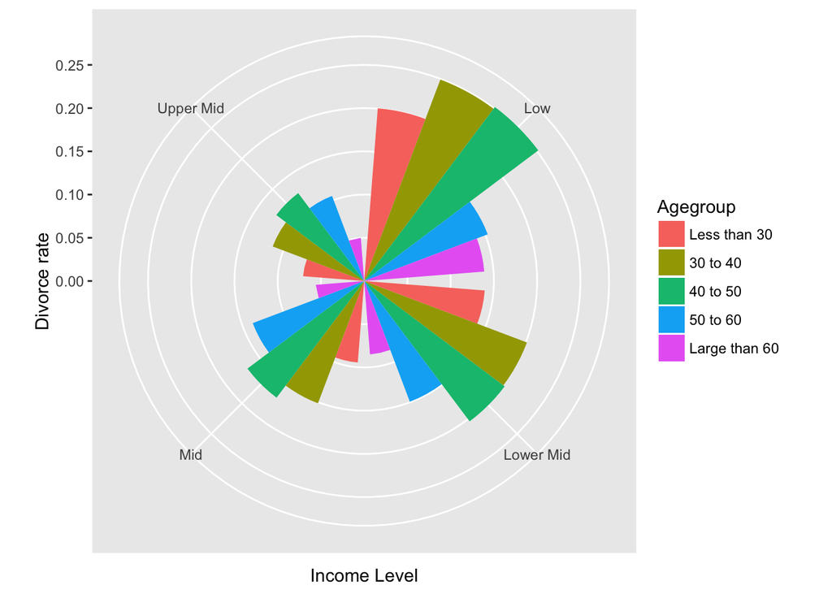

```r
Data$Agegroup <- ifelse(Data$AGEP < 30, "less than 30",
                        ifelse(Data$AGEP %in% c(30:40), "30 to 40",
                               ifelse(Data$AGEP %in% c(40:50), "40 to 50",
                                      ifelse(Data$AGEP %in% c(50:60), "50 to 60",
                                             ("Large than 60")))))
Data_Income2_Divrate1_age <- ddply(Data, .(Income2, Agegroup), summarise, n = length(MARHD), Div_rate1 = (sum(MAR == 3) + sum(MAR == 4))/length(MAR))
Income2_age_Divrate1<- ggplot(Data_Income2_Divrate1_age, aes(x = factor(Income2), y = Div_rate1, fill = Agegroup)) +
                      geom_bar(stat = "identity", position = "dodge") +
                      coord_polar(theta = "x") +
                      xlab("Income Level") + ylab("Divorce rate") +
                      scale_fill_discrete(labels = c("Less than 30", "30 to 40", "40 to 50", "50 to 60", "Large than 60"))
Income2_age_Divrate1
```

##### The results are almost the same with the previous results.

## 3.2 Another way to define divorce rate.

##### Divrate2 = poeple who have been divorce in the past 12 months / people who have been married in the past 12 months

### 3.2.1 Only divorce rate and Income level.

[figure not shown]

```r
Data_Income2_Divrate2 <- ddply(Data, .(Income2), summarise, n = length(MARHD), Div_rate2 = (sum(MARHD == 1))/(sum(MARHM == 1)))

Income2_Divrate2 <- ggplot(Data_Income2_Divrate1, aes(x = factor(Income2), y = Div_rate2, fill = Income2)) +
                     geom_bar(stat = "identity", position = "dodge") +
                     coord_polar(theta = "x") +
                     xlab("Income Level") + ylab("Divorce rate")
Income2_Divrate1
```

### 3.2.2 The effect of gender.

[figure not shown]

```r
Data_Income2_Divrate2_sex <- ddply(Data, .(Income2, SEX), summarise, n = length(MARHD), Div_rate2 = (sum(MARHD == 1))/(sum(MARHM == 1)))

Income2_sex_Divrate1<- ggplot(Data_Income2_Divrate2_sex, aes(x = factor(Income1), y = Div_rate2, fill = SEX)) +
                     geom_bar(stat = "identity", position = "dodge") +
                     coord_polar(theta = "x") +
                     xlab("Income Level") + ylab("Divorce rate") +
                     scale_fill_discrete(labels = c("Male", "Female"))
Income1_sex_Divrate1
```

### 3.2.3 The effect of agegroup.

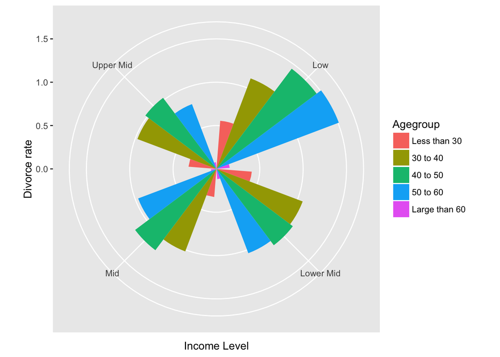

```r
Data$Agegroup <- ifelse(Data$AGEP < 30, "less than 30",
                        ifelse(Data$AGEP %in% c(30:40), "30 to 40",
                               ifelse(Data$AGEP %in% c(40:50), "40 to 50",
                                      ifelse(Data$AGEP %in% c(50:60), "50 to 60",
                                             ("Large than 60")))))
Data_Income2_Divrate2_age <- ddply(Data, .(Income2, Agegroup), summarise, n = length(MARHD), Div_rate2 = (sum(MARHD == 1))/(sum(MARHM == 1)))
Income2_age_Divrate2<- ggplot(Data_Income2_Divrate2_age, aes(x = factor(Income2), y = Div_rate2, fill = Agegroup)) +
                      geom_bar(stat = "identity", position = "dodge") +
                      coord_polar(theta = "x") +
                      xlab("Income Level") + ylab("Divorce rate") +
                      scale_fill_discrete(labels = c("Less than 30", "30 to 40", "40 to 50", "50 to 60", "Large than 60"))
Income2_age_Divrate2
```

# 4. Conclusion